# NEM spot price risk factors

2022-03-27

## Introduction

This report presents results related to identifying the factors driving variation (i.e. risk) in spot prices in the National Electricity Market (NEM).

## Outline in this report

- Descriptive statistics showing the NEM spot price risk profile
- Exploring causal factors
- Drawing conclusions

## Data collection

Data sets were sourced from:

- [Australian Electricity Market Operator](https://aemo.com.au/)
- [National Oceanic and Atmospheric Administration via the worldMet library](https://www.ncei.noaa.gov/products/land-based-station/global-historical-climatology-network-daily)
- [NASA’s Prediction of Worldwide Energy Resource (POWER)](https://power.larc.nasa.gov/data-access-viewer/)

## Data notes

Time frame of data collection is 1 January 2021 to 28 February 2022, inclusive. Note that prior to 1 October 2021, the NEM data are reported in 30-minute market settlement intervals. After 1 October 2021, market settlement intervals changed to 5 minutes to match the 5-minute dispatch interval. Consequently, data after 1 October 2021 are aggregated to 30-minute.

NEM market data are confined to the New South Wales (NSW) region. A single weather station is used to associate variation in NEM spot price ($/MWh) and quantity (MWh) to variation in air temperature and solar irradiation.

[Click on this link for more information about the NEM](https://aemo.com.au/-/media/Files/Electricity/NEM/National-Electricity-Market-Fact-Sheet.pdf)

## Summary statistics

Here is a table of the collated data set:

| Outlier_H_L | Price_mean | Quantity_mean | Price_sd | Quantity_sd |
| --- | --- | --- | --- | --- |
| high outlier | 658.28733 | 10051.017 | 1072.15637 | 1072.1539 |
| low outlier | -19.93266 | 5795.484 | 20.72997 | 803.1203 |
| normal | 60.73038 | 7537.910 | 32.99946 | 1134.0536 |

During market intervals that are within the 2.5% and the 97.5% percentile range, the spot price averages $60.73/MWh +/- $33.00/MWh and quantity averages 7,537.91 MWh +/- 1,134 MWh. Note that periods of very low prices, the average is negative and the quantity range is 5,795.48 MWh +/- 803.12 MWh. During percentile market intervals, price averages $658.29/MWh with an average range of +$1,072.17/MWh.

## Histogram of NEM NSW spot price

Excluding outliers, here is a histogram of spot prices averaged over 30-minute intervals:

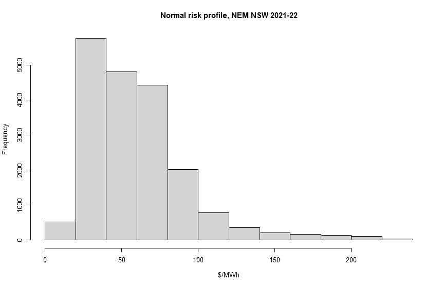

Histogram of spot prices excluding outliers

## Histogram of NEM NSW spot price spikes

NEM spot prices are prone to spikes to a minimum of -$1,000/MWh (price floor) and $15,000/MWh (price cap). Note that the histogram suggests pronounced skewness and peakiness.

[figure not shown]

Histogram of spot price outliers

## Probability Density Function (PDF)

Given the observed peakiness and skewness in NEM spot prices, it is useful to relate this to a particular PDF. Here, excluding outliers, spot price variation is compared to the gamma and log-normal PDFs.

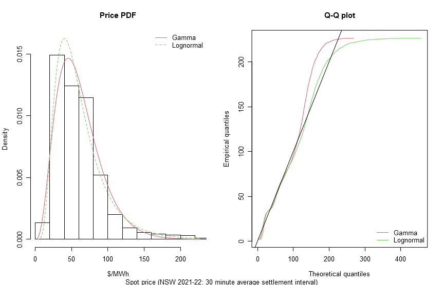

## Price versus quantity

A scatter plot of quantity (MWh) and spot price ($/MWh) suggests a direct, albeit noisy, relationship:

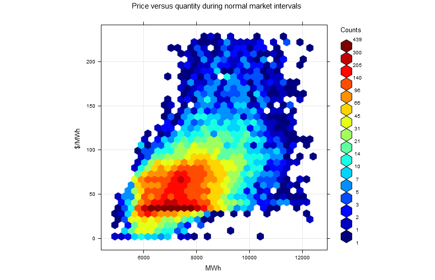

## Seasonal patterns

Using a calendar plot, we can explore quantity variation over the whole of calendar year 2021:

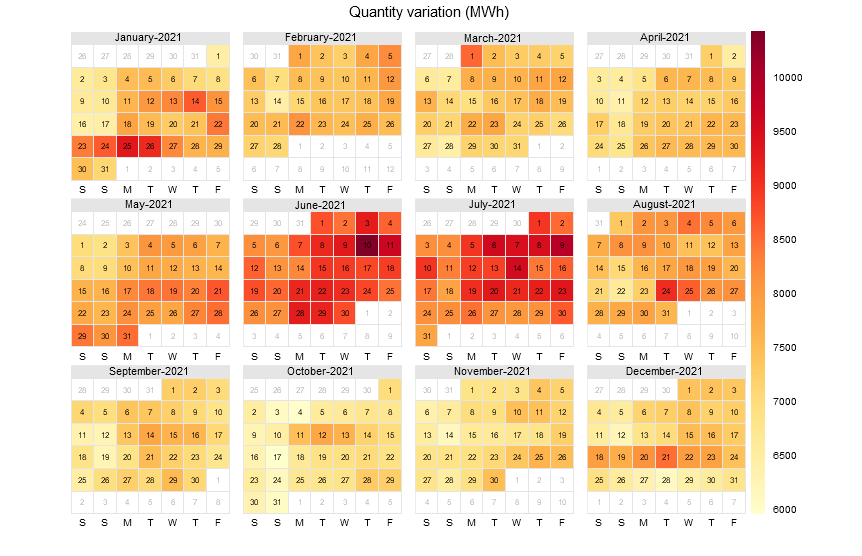

## Air temperature and quantity

The demand for electricity suggests a seasonal cycle, which is partly influenced by seasonal air temperature variation:

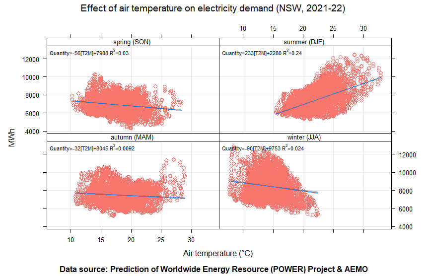

## Solar irradiance and normal demand

Across three seasons, higher solar irradiance suggests lower spot prices:

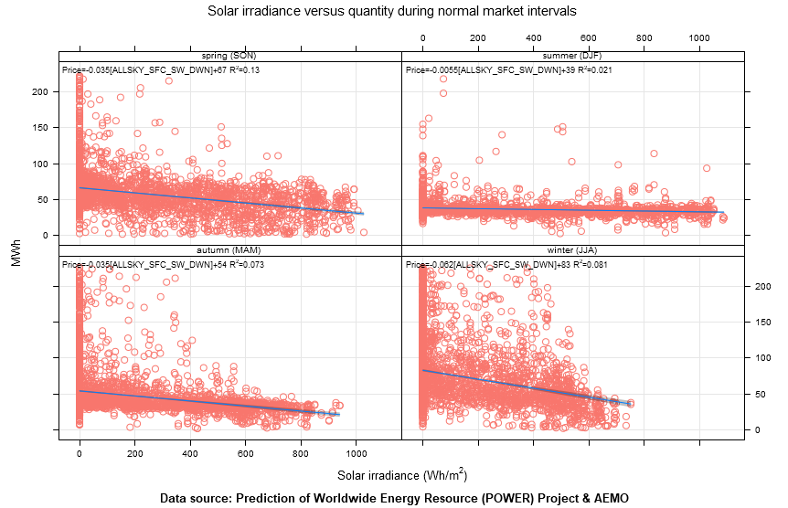

## Risk of spikes in through the year

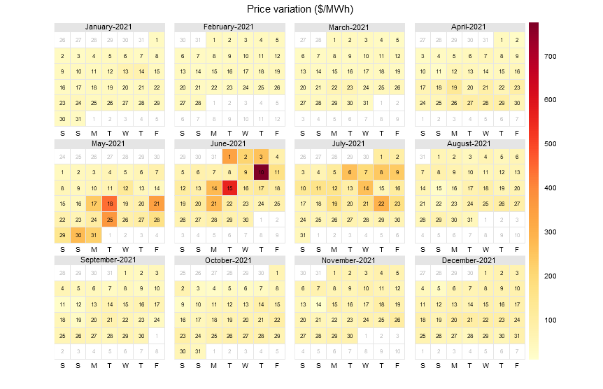

## Solar irradiance and demand during price spikes

This chart suggests that solar irradiance contributes to low percentile spot prices, but not to high percentile spot prices:

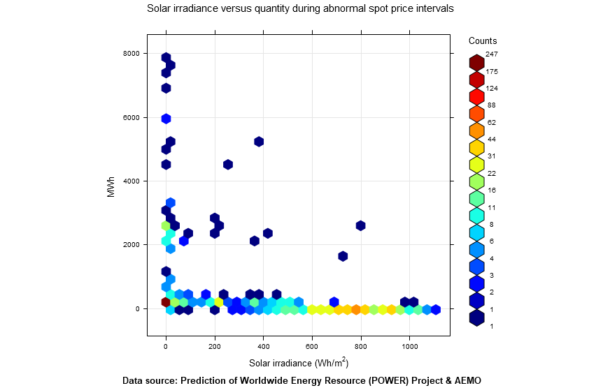

## Share of solar generation

- According to the AEMO’s [NEM Registration and Exemption List](https://www.aemo.com.au/-/media/files/electricity/nem/participant_information/nem-registration-and-exemption-list.xls?la=en) renewable electricity generation accounts for 55% of total generation. A relatively small proportion is solar power. However, [according to Energy NSW](https://www.energy.nsw.gov.au/renewables/renewable-generation/solar-energy), there is in excess of 4,000 MW of solar power capacity installed